# A3: Incarceration

```r
library(dplyr)
```

```r
library(ggplot2)
library(tidyverse)
df <- read.csv("https://github.com/melaniewalsh/Neat-Datasets/raw/main/us-prison-jail-rates-1990-WA.csv")
```

### Introduction

The problem domain I am exploring is the distribution of incarceration rates across different races in the Washington State. The variables I choose are aapi_prison_pop_rate, black_prison_pop_rate, latinx_prison_pop_rate, native_prison_pop_rate, and white_prison_pop_rate. The reason I choose these variables is that by directly comparing these variables that represents different races of people, we can better understand the incarceration rates of different racial groups and compare them to see if there is potential discrimination and unfairness.

### Summary Information

```r
summary_aapi <- df %>%
  summarise(
    mean = mean(aapi_prison_pop_rate, na.rm = TRUE),
    min = min(aapi_prison_pop_rate, na.rm = TRUE),
    max = max(aapi_prison_pop_rate, na.rm = TRUE),
    median = median(aapi_prison_pop_rate, na.rm = TRUE),
    sd = sd(aapi_prison_pop_rate, na.rm = TRUE)
  )

print(summary_aapi)
```

```
##       mean min    max median       sd
## 1 57.88149   0 675.68 29.785 78.65467
```

```r
summary_black <- df %>%
  summarise(
    mean = mean(black_prison_pop_rate, na.rm = TRUE),
    min = min(black_prison_pop_rate, na.rm = TRUE),
    max = max(black_prison_pop_rate, na.rm = TRUE),
    median = median(black_prison_pop_rate, na.rm = TRUE),
    sd = sd(black_prison_pop_rate, na.rm = TRUE)
  )

print(summary_black)
```

```
##       mean min    max  median     sd
## 1 1922.378   0 8215.3 1738.77 1176.8
```

```r
summary_latinx <- df %>%
  summarise(
    mean = mean(latinx_prison_pop_rate, na.rm = TRUE),
    min = min(latinx_prison_pop_rate, na.rm = TRUE),
    max = max(latinx_prison_pop_rate, na.rm = TRUE),
    median = median(latinx_prison_pop_rate, na.rm = TRUE),
    sd = sd(latinx_prison_pop_rate, na.rm = TRUE)
  )

print(summary_latinx)
```

```
##       mean min     max median       sd
## 1 674.7796   0 6178.16 509.21 720.7297
```

```r
summary_native <- df %>%
  summarise(
    mean = mean(native_prison_pop_rate, na.rm = TRUE),
    min = min(native_prison_pop_rate, na.rm = TRUE),
    max = max(native_prison_pop_rate, na.rm = TRUE),
    median = median(native_prison_pop_rate, na.rm = TRUE),
    sd = sd(native_prison_pop_rate, na.rm = TRUE)
  )

print(summary_native)
```

```
##       mean min     max  median       sd
## 1 970.8833   0 4494.38 908.015 584.8158
```

```r
summary_white <- df %>%
  summarise(
    mean = mean(white_prison_pop_rate, na.rm = TRUE),
    min = min(white_prison_pop_rate, na.rm = TRUE),
    max = max(white_prison_pop_rate, na.rm = TRUE),
    median = median(white_prison_pop_rate, na.rm = TRUE),
    sd = sd(white_prison_pop_rate, na.rm = TRUE)
  )

print(summary_white)
```

```
##      mean   min     max  median       sd
## 1 351.606 41.92 1086.63 318.545 178.9225
```

```r
summary_year_black <- df %>%
  group_by(year) %>%
  summarise(
    mean = mean(black_prison_pop_rate, na.rm = TRUE),
    min = min(black_prison_pop_rate, na.rm = TRUE),
    max = max(black_prison_pop_rate, na.rm = TRUE),
    median = median(black_prison_pop_rate, na.rm = TRUE),
    sd = sd(black_prison_pop_rate, na.rm = TRUE)
  )
print(summary_year_black)
```

```
## # A tibble: 29 × 6
##     year  mean   min   max median    sd
##    <int> <dbl> <dbl> <dbl>  <dbl> <dbl>
##  1  1990 1847.    0  7381.  1185. 1830.
##  2  1991 2185.    0  8215.  1388. 2140.
##  3  1992 2025.    0  6667.  1542. 1763.
##  4  1993 1682.    0  4945.  1336. 1589.
##  5  1994 2084.    0  6599.  1868. 1720.
##  6  1995 2363.  820. 5440.  1825. 1367.
##  7  1996 2267.  920. 4462.  2240. 1006.
##  8  1997 2236.  635. 5007.  2001  1141.
##  9  1998 2289.    0  5548.  2055. 1363.
## 10  1999 2391. 1134. 5000   2176.  942.
## # ℹ 19 more rows
```

```r
highest_rate_year <- summary_year_black$year[which.max(summary_year_black$mean)]
lowest_rate_year <- summary_year_black$year[which.min(summary_year_black$mean)]
```

By looking at the summary information of incarceration of each race, it is easy to find out that black people have the highest mean, which is 1922.378 per 100,000 people per county, and it is way higher than the second highest mean, which is 970.8833 for native people. Moreover, black people also has the highest max(8215.3) and median(1738.77). Comparing with Asian American and Pacific Islander people, which only has 57.88149 for mean, 675.68 for max, and 29.785 for median. These are just some general information, but the huge gap between different races, and we can clearly see that black people are incarcerated at disproportionately high rates across time, the highest incarceration mean rate for black people is 2390.614, which is in 1999, and the lowest is 1366.395 in 2012.

### The Dataset

Who collected the data?

The data was collected by the Vera Institute of Justice.

How was the data collected or generated?

It was generated through a combination of surveys and administrative records.

Why was the data collected?

It was collected to provide a comprehensive view of the Washington prison and jail population.

How many observations (rows) are in your data?

1131

How many features (columns) are in the data?

23

What, if any, ethical questions or questions of power do you need to consider when working with this data?

I might need to consider the potential for bias in the data collection process.

What are possible limitations or problems with this data? (at least 200 words)

The dataset may not include all relevant variables that could impact incarceration rates, such as socioeconomic status, education level, or employment rate, which can certainly limit the scope of analysis and could lead to omitted variable bias, and omitted variable bias can make the result we find out insignificant, so we need to keep this possibility in mind. Another thing is that the data is likely reported by different jurisdictions, and each with their own methods of data collection and reporting standards, which could lead to inconsistencies or errors in the data. This could eventually lead to certain races to be underrepresented or overrepresented in the data, which could also cause biased results. One last thing, interpreting the data can be challenging because high incarceration rates could indicate high crime rates, but they could also indicate issues with the criminal justice system, such as racial bias or overly punitive laws. In our case, these two completely different situations definitely co-exist, and it is really hard for us to distinguish them because the data we get is very limited and might contains some bias. Furthermore, even if we can have all the information we want about each on of them in prison, it is still hard to tell whether there is a racial bias because there are too much information and cases and situations can vary very differently.

### Trends Over Time Chart

```r
df_long <- df %>%
  pivot_longer(
    cols = c(aapi_prison_pop_rate, black_prison_pop_rate, latinx_prison_pop_rate, native_prison_pop_rate,     white_prison_pop_rate),
    names_to = "race",
    values_to = "incarceration_rate"
  )
```

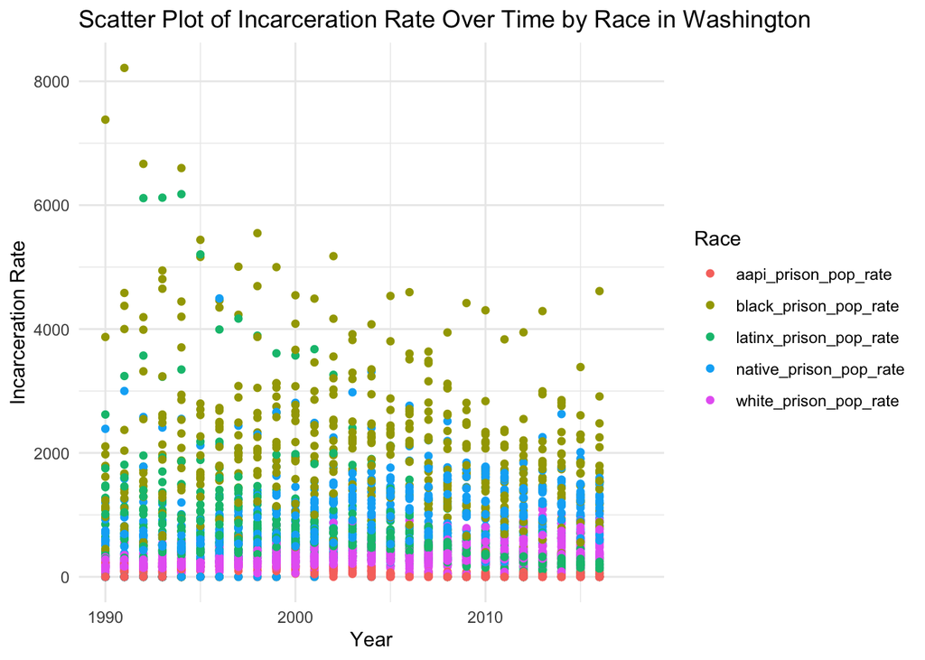

```r
ggplot(df_long, aes(x = year, y = incarceration_rate, color = race)) +
  geom_point() +
  labs(
    x = "Year",
    y = "Incarceration Rate",
    color = "Race",
    title = "Scatter Plot of Incarceration Rate Over Time by Race in Washington"
  ) +
  theme_minimal()
```

### Variable Comparison Chart

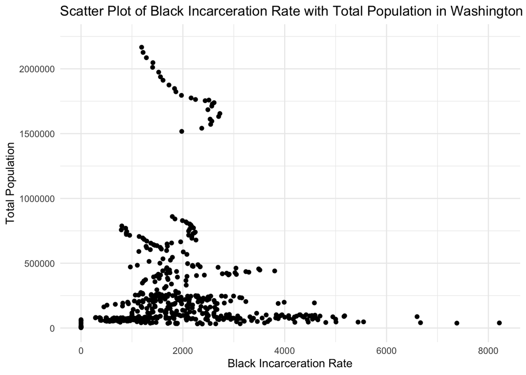

```r
ggplot(df, aes(x = black_prison_pop_rate, y = total_pop)) +
  geom_point() +
  labs(
    x = "Black Incarceration Rate",
    y = "Total Population",
    title = "Scatter Plot of Black Incarceration Rate with Total Population in Washington"
  ) +
  theme_minimal()
```

This chart can show the relationship between total population and black incarceration rate in Washington State. If the chart shows a positive relationship between these two variable, it can be interpreted that there are potential racial bias against black people, because one good reason for the situation that the more people there are, the more black people are incarcerated is that there is racial discrimination against black people, so the more black people there are, the more black people will be arrested. The chart showed here shows no clear pattern between total population and balck incarceration rate.

### Map

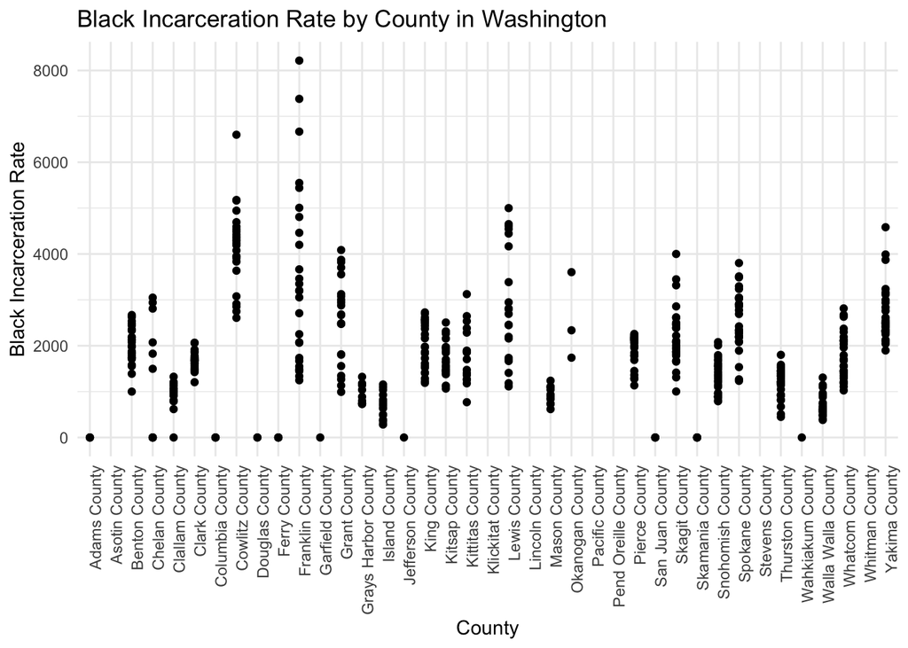

```r
ggplot(df, aes(x = reorder(county_name, -black_prison_pop_rate), y = black_prison_pop_rate)) +
  geom_point() +
  labs(
    x = "County",
    y = "Black Incarceration Rate",
    title = "Black Incarceration Rate by County in Washington"
  ) +
  theme_minimal() +
  theme(axis.text.x = element_text(angle = 90, hjust = 1))
```

The reason why I include this chart is to find out the difference of black incarceration rate across different counties in Washington State. The chart shows that Cowlitz and Franklin counties has higher black incarceration rates than others. By looking at other information of these two counties, we might be able to find patterns and even reasons of why these two counties has higher black incarceration artes.